# Posterior predictive distributions and checks

Author

Hans Elliott

## Introduction

Let’s describe a general model for a data generating process as $y \sim p(y | \theta)$, with data $y$ generated from the family of probability distributions $p$ indexed with parameter $\theta$.

There is no doubt that there is uncertainty in $y$ since it is a random variable, by construction, and thus can take on a range of values based on its probability distribution.

In the Bayesian setup, we model uncertainty over $\theta$ by assuming it comes from its own distribution, with prior $p(\theta)$. So our full data model is:
$$y \sim p(y | \theta) \\
\theta \sim p(\theta)$$

Next we fit our model (using some method or another) to data using Bayes’ theorem to get the posterior distribution of $\theta$ given the data, $p(\theta | y) \propto p(y | \theta) p(\theta)$ - i.e., the posterior distribution is proportional to the likelihood times the prior.

This gives us an updated probability distribution over possible values for $\theta$.

Next, it is common to sample from the **posterior predictive distribution**, where the idea is to generate new observations of $y$ by simulating the data generating process that we defined above - where $\theta \sim p(\theta | y)$ and $y \sim p(y | \theta)$.

This process incorporates the uncertainty from 2 different sources:

- Over the parameter values, i.e., the uncertainty in $\theta$, described by posterior $p(\theta | y)$
- *And* the uncertainty in the sampling distribution itself, i.e., the uncertainty that comes from the data being generated by $p(y | \theta)$.

So, while it may be tempting to plug in a single value of $\theta$, say a $\hat{\theta}$, into the sampling distribution to generate new values of $y$, this would ignore the uncertainty in $\theta$ and cause the predictive distribution to be too narrow.

These 2 sources of uncertainty are sometimes referred to as **epistemic** and **aleatoric** uncertainty, where epistemic uncertainty arises from $\theta$ being unkown and estimated based on a finite sample of data, and aleatoric uncertainty arising because even if we knew $\theta$ exactly, there is still uncertainty in the values of $y$ (by definition, since $y$ is a random variable, and so there is some missing information about its generation).

An obvious reason to do posterior predictive sampling is if we are interested in making probabilistic predictions of $y$, which, again, should incorporate uncertainty in the parameter $\theta$ and in the sampling distribution $p(y | \theta)$.

But even if we are primarily interested in $\theta$, it is still important to analyze the posterior predictive distribution because it indicates the fit of the model - if we can’t use our model to generate a simulated distribution of $y$ that looks and behaves something like the actual distribution of $y$ (in our observed data), then our model is not doing well.

In practice, this distribution is going to be difficult to calculate analytically, but we can estimate it using sampling.

This is essentially a 2 step process, repeated many times:

- We sample a single $\theta$ from its posterior distribution, $\theta_i \sim p(\theta | y)$, which implies a sampling distribution for $y$, such that $y \sim p(y | \theta_i)$.
- Then we sample a single draw from this sampling distribution, which we’ll call $y^{rep}_i$.
  - We refer to these draws as $y^{rep}$ since if we had covariates, we’d be simulating outcome values over the observed values of the covariates to perform this check - i.e., directly replicating the theoretical process that created the data sample $y$. We could also simulate $y$ for new covariate values if we were interested in prediction, in which case we can still use this process to generate a posterior predictive distribution, but will generally use different notation (often $\tilde{y}$).

By repeating many times, we build up a collection of $y^{rep}$ values that each came from different variations of $\theta_i$ (each implying variations of sampling distribution $p(y | \theta_i)$), and this collection of samples approximates the **posterior predictive distribution**: $p(y^{rep} | y)$

Formally the posterior predictive distribution can be defined as:

$$p(y^{rep} | y) = \int p(y^{rep} | \theta) p(\theta | y) d\theta$$

The product under the integral reduces to the joint posterior density, $p(y^{rep}, \theta | y)$ (since $p(a,b) = p(a|b)p(b)$), so that integrating over $\theta$ is just marginalizing out the parameters, leaving the predictive density of the data (see [here](https://mc-stan.org/docs/stan-users-guide/posterior-prediction.html)).

## Example 1: Poisson model

For a simple example, consider a Poisson distribution with $\theta = \lambda$.

We can imagine the extreme case where we are very certain about $\lambda$ (so minimal epistemic uncertainty), so that the distribution over $\lambda$ spikes around its likely value, and samples from the distribution, $\lambda_i$, will be more-or-less identical during each iteration - practically fixed. Therefore, the implied sampling probability distribution $p(y | \lambda_i)$ will also not really change from iteration to iteration, and the values of $y^{rep}$ sampled will essentially be governed by the *same* sampling distribution at each iteration. Thus, after repeating the generative process many times we’d expect the distribution of $y^{rep}$ values to closely match that of the practically-fixed sampling distribution.

In fact, if we were absolutely certain about the value of $\lambda$ (0 epistemic uncertainty), say we know $\lambda=3$, then we could generate $y^{rep}$ using a simple random number generator (though this is not Bayesian):

```r
rpois(1000, lambda = 3)
```

But imagine that there is a small amount of uncertainty in $\lambda$ which we model with a probability distribution that spikes around the value $3$, as shown by the first histogram below. Then each time we sample a $\lambda_i$, the implied sampling distribution will not change much, as shown by the random PMFs in the middle figure.  
As a result, accumulating $y^{rep}$ values from this process yields a distribution that closely resembles $Poisson(3)$, as seen in the bottom figure.

**Posterior predictive distribution under minimal epistemic uncertainty**

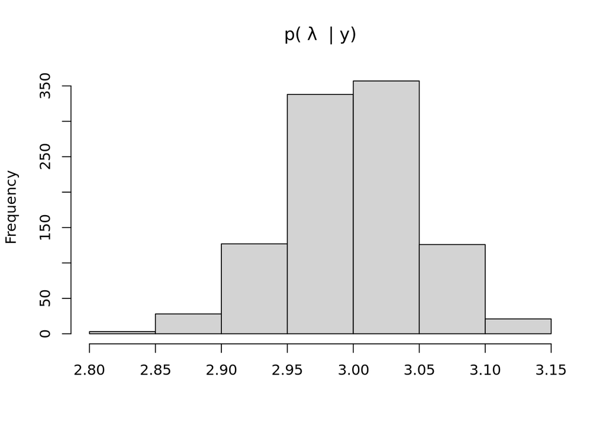

```r
n <- 1000

# p(\lambda | y)
l_rep <- abs(rnorm(n, mean = 3, sd = 0.05))
hist(l_rep, main = expression("p(" ~ lambda ~ " | y)"), xlab = "")
```

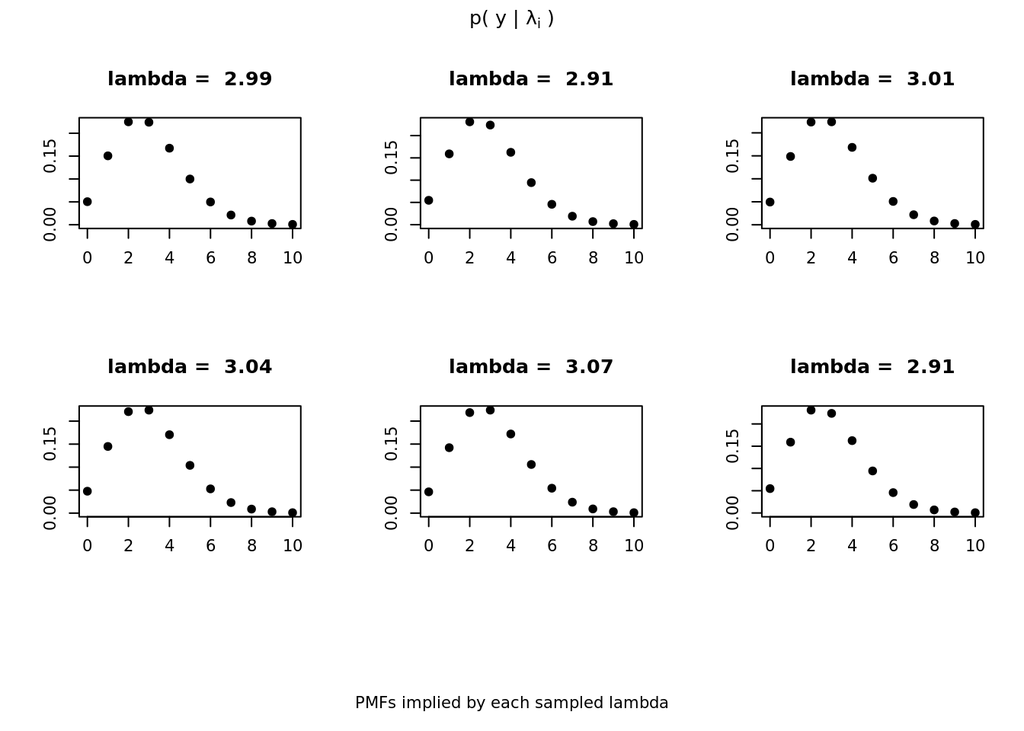

```r
# p(y | \lambda)
par(mfrow = c(2, 3), oma = c(6,0,2,0))
xp <- seq(0, 10, by = 1)
for (. in 1:6) {
  .l <- sample(l_rep, 1)
  plot(xp, dpois(xp, lambda = .l),
       ylab = "", xlab = "",
       main = paste("lambda = ", round(.l, 2)),
       pch = 19)
}
title(main = expression("p(" ~ "y" ~ "|" ~ lambda[i] ~ ")"),
      sub = "PMFs implied by each sampled lambda",
      outer = TRUE)
```

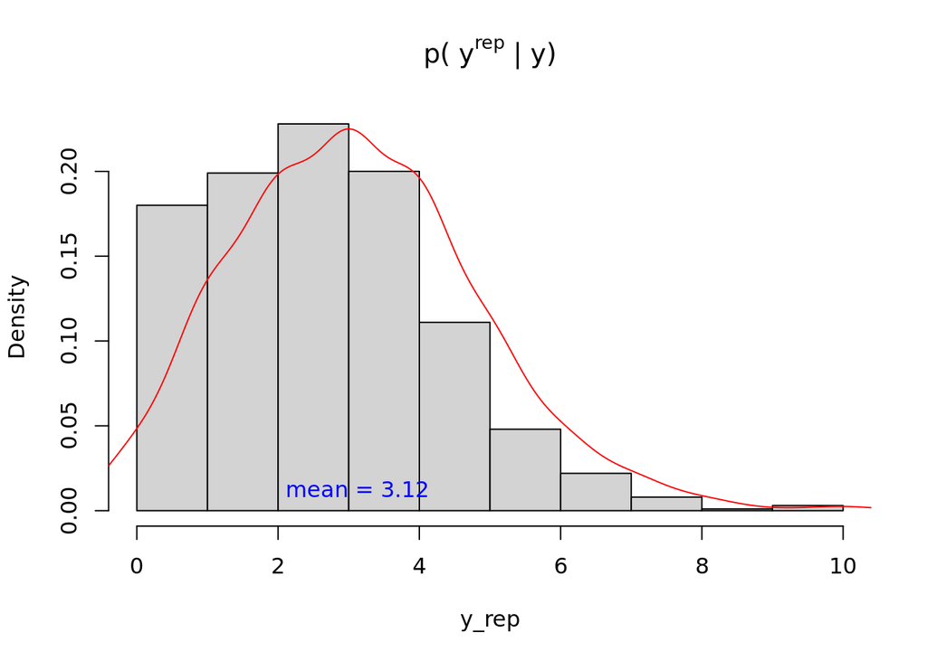

```r
# p(y^{rep} | y)
y_rep <- rpois(n, lambda = l_rep)
hist(y_rep, probability = TRUE, main = expression("p(" ~ "y"^"rep" ~ "| y)"))
lines(density(y_rep, bw = 0.5), col = "red")
text(mean(y_rep), 0.,
     paste("mean =", round(mean(y_rep), 2)),
     pos = 3, col = "blue")
```

However, if there is lots of uncertainty around $\lambda$ so that its own distribution is relatively spread out, then each time we sample a $\lambda_i$ it may imply a very different sampling distribution $p(y | \lambda_i)$, so that each time we draw a $y_{rep}$ value it could be coming from a very different distribution, resulting in a posterior predictive distribution $p(y^{rep}|y)$ that incorporates much more uncertainty and may not closely resemble a single sampling distribution.

In the below figures, the only tweak is that the for the fake posterior distribution of $\lambda$, its standard deviation is increased from $0.05$ to $2$, causing its distribution to be much more spread out. This leads to much wider variety in the $\lambda_i$’s being sampled.  
The resulting posterior predictive distribution is still centered around $3$ but is significantly more spread out relative to the above example, reflecting greater uncertainty.

**Posterior predictive distribution under more epistemic uncertainty**

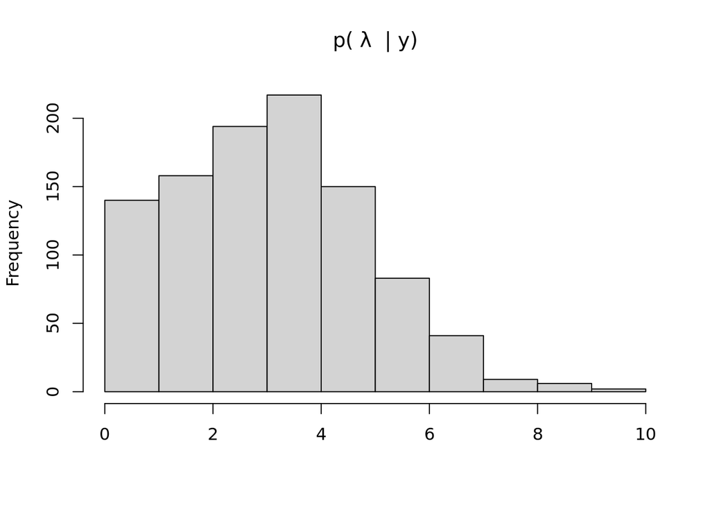

```r
n <- 1000

# p(\lambda | y)
l_rep <- abs(rnorm(n, mean = 3, sd = 2))
hist(l_rep, main = expression("p(" ~ lambda ~ " | y)"), xlab = "")
```

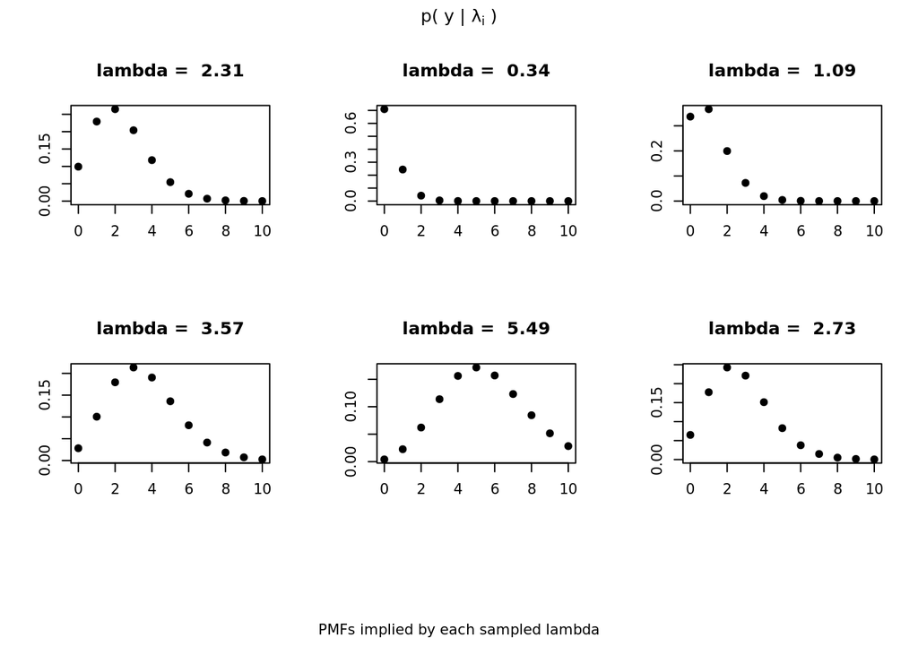

```r
# p(y | \lambda)
par(mfrow = c(2, 3), oma = c(6,0,2,0))
xp <- seq(0, 10, by = 1)
for (. in 1:6) {
  .l <- sample(l_rep, 1)
  plot(xp, dpois(xp, lambda = .l),
       ylab = "", xlab = "",
       main = paste("lambda = ", round(.l, 2)),
       pch = 19)
}
title(main = expression("p(" ~ "y" ~ "|" ~ lambda[i] ~ ")"),
      sub = "PMFs implied by each sampled lambda",
      outer = TRUE)
```

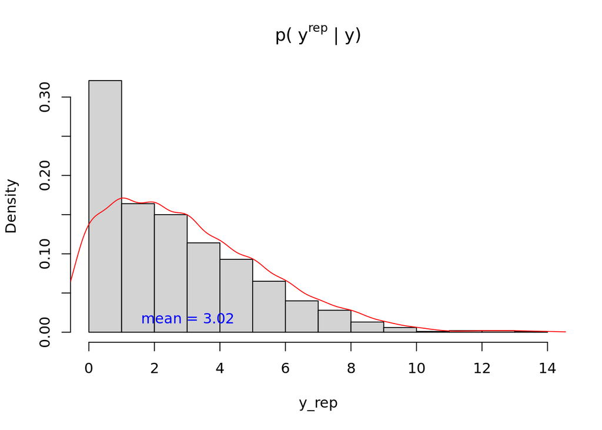

```r
# p(y^{rep} | y)
y_rep <- rpois(n, lambda = l_rep)
hist(y_rep, probability = TRUE, main = expression("p(" ~ "y"^"rep" ~ "| y)"))
lines(density(y_rep, bw = 0.5), col = "red")
text(mean(y_rep), 0.,
     paste("mean =", round(mean(y_rep), 2)),
     pos = 3, col = "blue")
```

Again, the idea of posterior predictive checks is to confirm that our model is able to generate data that looks something like the observed data.  
The first level is to just visually compare the historgrams of your $y^{rep}$ values to the observed data to determine how things look, but once you’re able to calculate $y^{rep}$ values you can do much more interesting things like estimate distributions over differences between the posterior predictive mean and the observed data mean, estimate event probabilities, etc.  
See the [Stan user manual](https://mc-stan.org/docs/stan-users-guide/posterior-predictive-checks.html) for more ideas.

I found it helpful to see this process play out dynamically in Ben Lambert’s video:  
https://www.youtube.com/watch?v=TMnXQ6G6E5Y&ab_channel=BenLambert

## Example 2 : Linear Regression

As a slightly more complicated example, imagine $y \sim \text{Normal}(\alpha + x \beta, \sigma_{\epsilon}^2)$, so $\theta = (\alpha, \beta, \sigma_{\epsilon})$, which could also be written $y = \alpha + x \beta + \epsilon$ where $\epsilon \sim N(0, \sigma_\epsilon^2)$.

Here we would define priors over $\alpha$, $\beta$, and $\sigma_{\epsilon}$, and then fit the model to some data to get posterior distributions over these parameters.

The pretend posterior distributions are specified below.  
To generate the posterior predictive distribution, we first simulate a value for each of these parameters:

```r
# p(\theta | y) ## after fitting, pretend these are the posterior distributions
alpha_rep <- rnorm(1, mean = -0.95, sd = 0.5)
beta_rep <- rnorm(1, mean = 3.1, sd = 0.16)
sig_rep <- abs(rnorm(1, mean = 2.1, sd = 0.36))

cat("THETA:\n",
    " alpha: ", alpha_rep, "\n",
    " beta: ", beta_rep, "\n",
    " sigma_eps: ", sig_rep, "\n")
```

```
THETA:
  alpha:  -1.202126
  beta:  3.394602
  sigma_eps:  2.753049
```

Next we fix these parameter values (“condition on them”) and this defines a probability distribution (from the Normal family) at each value of $x$. For example, here are the distributions at some different values of $x$:

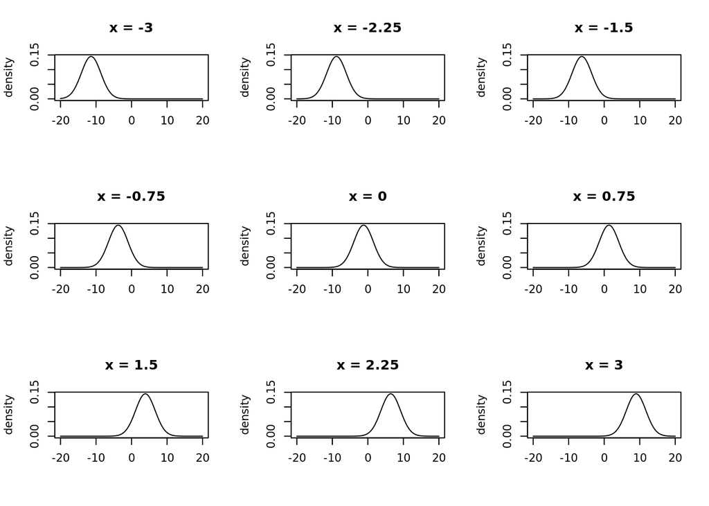

```r
# p(y | \theta_i)
par(mfrow = c(3,3))
for (x in seq(-3, 3, length.out = 9)) {
  quantiles <- seq(-20, 20, length.out = 1000)
  pdf <- dnorm(quantiles, mean = alpha_rep + beta_rep * x, sd = sig_rep)

  plot(quantiles, pdf, type = "l", xlab = "", ylab = "density", main = paste("x =", x))
}
```

Next we would repeat this process over and over to generate a colllection of $y^{rep}$ values, which would give us a sense of the posterior predictive distribution $p(y^{rep} | y)$.

For example, for $x = 3$:

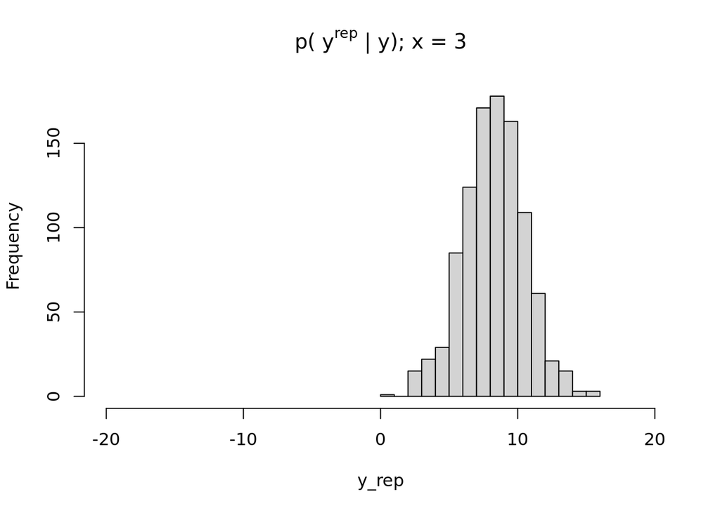

```r
# p(y^{rep} | y)

y_rep <- numeric(1000)
for (i in 1:length(y_rep)) {
  alpha_rep <- rnorm(1, mean = -0.95, sd = 0.5)
  beta_rep <- rnorm(1, mean = 3.1, sd = 0.16)
  sig_rep <- abs(rnorm(1, mean = 2.1, sd = 0.36))
  y_rep[i] <- rnorm(1, mean = alpha_rep + beta_rep * 3, sd = sig_rep)
}

hist(y_rep, breaks = 20, xlim = c(-20, 20),
     main = expression("p(" ~ "y"^"rep" ~ "| y); x = 3"))
```

It looks quite a bit like the PDF seen for $x = 3$ in the previous figure, because the fake posterior distributions for $\alpha$, $\beta$, and $\sigma_{\epsilon}$ have low variance (so not much epistemic uncertainty).

If we jack up the variance in the parameter’s posterior distributions:

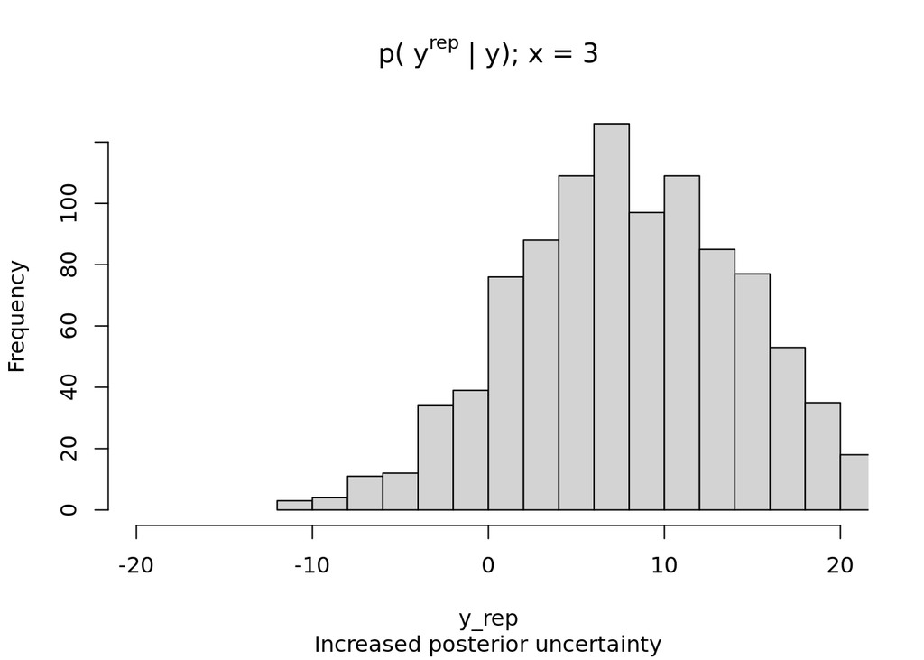

```r
y_rep <- numeric(1000)
for (i in 1:length(y_rep)) {
  alpha_rep <- rnorm(1, mean = -0.95, sd = 2)
  beta_rep <- rnorm(1, mean = 3.1, sd = 2)
  sig_rep <- abs(rnorm(1, mean = 2.1, sd = 1))
  y_rep[i] <- rnorm(1, mean = alpha_rep + beta_rep * 3, sd = sig_rep)
}

hist(y_rep, breaks = 20, xlim = c(-20, 20),
     main = expression("p(" ~ "y"^"rep" ~ "| y); x = 3"),
     sub = "Increased posterior uncertainty")
```

In general, we don’t have to condition on an $x$ value while analyzing the posterior predictive. We could just look at the entire distribution of $y^{rep}$ values and compare with the entire distribution of observed $y$.

For example, pretend we have the below data:

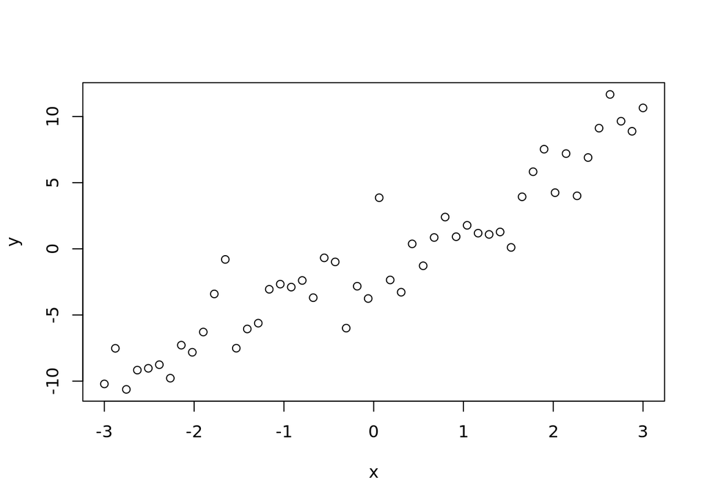

```r
.n <- 50
x <- seq(-3, 3, length.out = .n)
y <- rnorm(.n, mean = -1 + 3 * x, sd = 2)

plot(x, y)
```

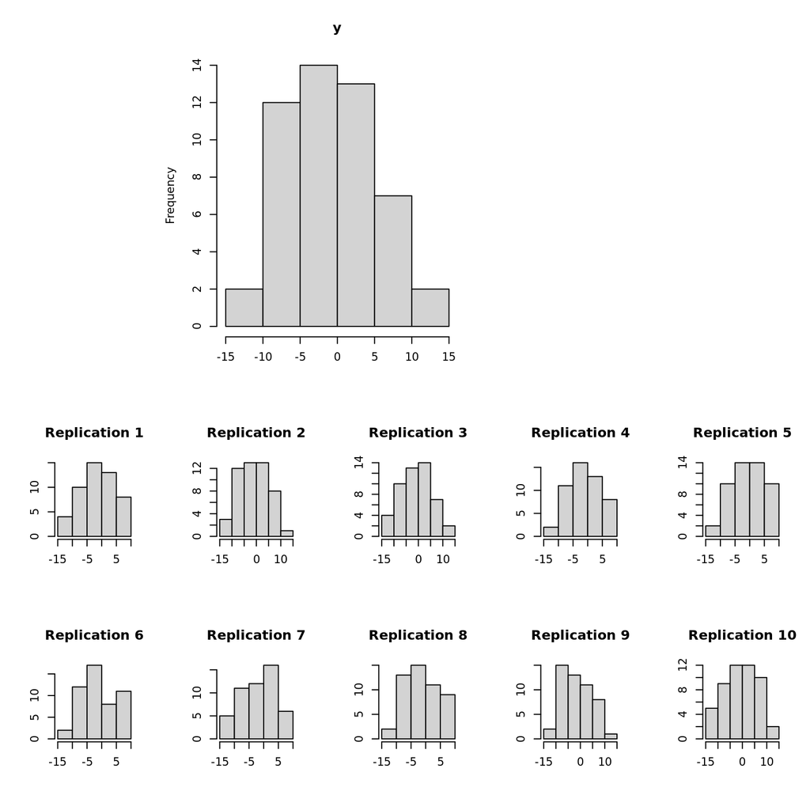

```r
y_rep <- matrix(nrow = length(x),
                ncol = 100) ## number of replications

for (i in seq(1, ncol(y_rep))) {
  alpha_rep <- rnorm(1, mean = -0.95, sd = 0.5)
  beta_rep <- rnorm(1, mean = 3.1, sd = 0.16)
  sig_rep <- abs(rnorm(1, mean = 2.1, sd = 0.36))
  y_rep[, i] <- rnorm(length(x),
                      mean = alpha_rep + beta_rep * x,
                      sd = sig_rep)
}

layout(matrix(c(0,1,1,0,0, 0,1,1,0,0, 2,3,4,5,6, 7,8,9,10,11),
              nrow = 4, byrow = TRUE))

hist(y, main = "y", xlab = "")
for (i in seq(1, 10)) {
  hist(y_rep[, i], main = paste("Replication", i), xlab = "", ylab = "")
}
```

Or as a scatter plot:

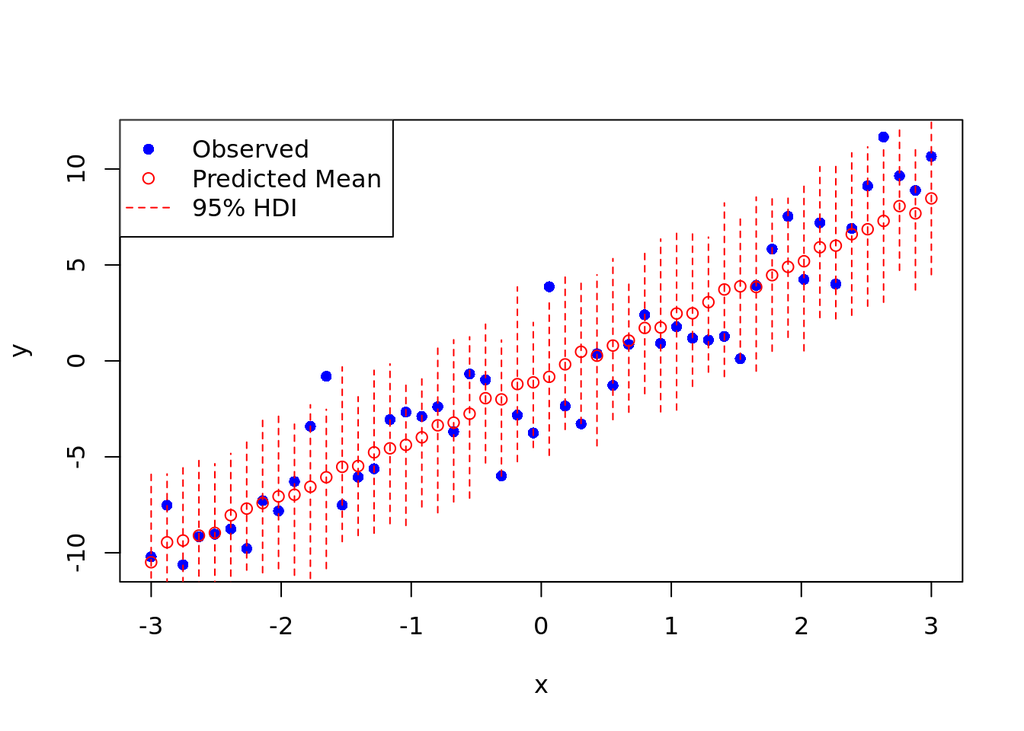

```r
y_mean <- rowMeans(y_rep)
y_hdi <- t(apply(y_rep, 1, quantile, probs = c(0.025, 0.975)))

plot(x, y, col = "blue", pch = 16)
points(x, y_mean, col = "red", pch = 1)
segments(x, y_hdi[, 1], x, y_hdi[, 2], col = "red", lty = 2)
legend("topleft",
       legend = c("Observed", "Predicted Mean", "95% HDI"),
       col = c("blue", "red", "red"),
       pch = c(16, 1, NA),
       lty = c(NA, NA, 2))
```

In Stan, we can sample from the posterior predictive distribution by laying out the process described above in the `generated quantities` block.

For example:

```
...
generated quantities {
  vector[N] y_rep;
  for (i in 1:N) {
    y_rep[i] = normal_rng(alpha + beta * x[i], sigma);
  }
}
```

During each iteration of MCMC, after Stan has sampled a draw of each parameter $\alpha$, $\beta$, and $\sigma$, it runs the generated quantities block using the sampled values to generate a $y^{rep}$ value for each $x$ value ($x$ would be defined in the `data` block and the parameters defined in the `parameter` block.

#### Helpful resources:

https://mc-stan.org/docs/stan-users-guide/posterior-prediction.html

https://mc-stan.org/docs/stan-users-guide/posterior-predictive-checks.html

https://mc-stan.org/docs/cmdstan-guide/generate_quantities_config.html